# BIOS 667 - Lecture 7: Modeling the Covariance (Ch. 7)

## Implied Correlation Heatmaps

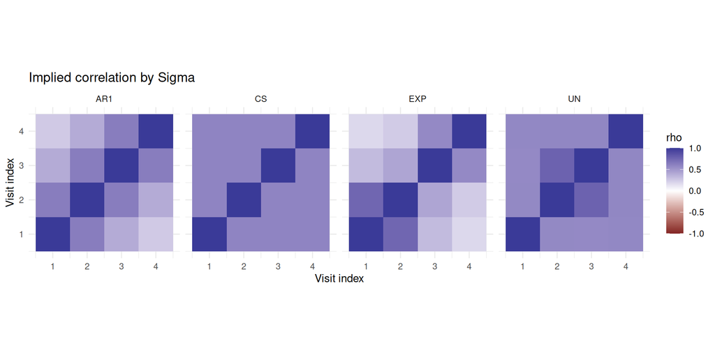

## Model Comparison (REML-logLik / AIC; BIC for reference)

```r
mods <- list(
  UN_het   = gls_un,
  CS       = gls_cs,
  AR1      = gls_ar1,
  AR1het   = gls_ar1_het,
  EXP      = gls_exp,
  EXP_het  = gls_exp_het,
  EXP_nug  = gls_exp_nug
)

# Rank by AIC (FLW's recommended non-nested criterion); BIC for reference only.
data.frame(
  model  = names(mods),
  AIC    = sapply(mods, AIC),
  BIC    = sapply(mods, BIC),   # reference only; FLW p. 179 advises against for Sigma
  logLik = sapply(mods, logLik)
) |>
  dplyr::arrange(AIC)
```

## Model Comparison (REML-logLik / AIC; BIC for reference)

```
          model      AIC      BIC    logLik
UN_het   UN_het 2452.076 2523.559 -1208.038
AR1het   AR1het 2477.640 2529.266 -1225.820
CS           CS 2480.621 2520.334 -1230.311
EXP_nug EXP_nug 2482.503 2526.187 -1230.251
AR1         AR1 2492.631 2532.343 -1236.315
EXP_het EXP_het 2513.537 2565.164 -1243.769
EXP         EXP 2521.918 2561.631 -1250.959
```

## Candidate $\Sigma$ (REML; Same Fixed Effects)

```r
# Independence (for boundary LRT demo)
gls_ind <- gls(y ~ group * time_f, data = long, method = "REML")

# CS, AR(1), Exponential, UN (hetero)
gls_cs  <- gls(y ~ group * time_f, data = long,
               correlation = corCompSymm(value = 0.2, form = ~ 1 | id), method = "REML")

gls_ar1 <- gls(y ~ group * time_f, data = long,
               correlation = corAR1(value = 0.2, form = ~ time_idx | id), method = "REML")

gls_exp <- gls(y ~ group * time_f, data = long,
               correlation = corExp(value = 0.2, form = ~ time_num | id), method = "REML")

gls_un  <- gls(y ~ group * time_f, data = long,
               correlation = corSymm(value = start_vec_un, form = ~ time_idx | id),
               weights     = w_time, method = "REML")
```

## Candidate $\Sigma$ (REML; Same Fixed Effects)

## Adding ARH(1) for Robustness

```r
start_rho <- 0.4
gls_ar1_het <- gls(y ~ group * time_f, data = long,
                   correlation = corAR1(value = start_rho, form = ~ time_idx | id),
                   weights     = w_time, method = "REML")
```

## Adding ARH(1) for Robustness

## Compare $\Sigma$ by REML-AIC (BIC for reference)

```r
mods <- list(
  IND     = gls_ind,
  CS      = gls_cs,
  AR1     = gls_ar1,
  AR1het  = gls_ar1_het,
  EXP     = gls_exp,
  UN_het  = gls_un
)

# AIC ranks non-nested candidates; for nested pairs use the REML-LRT.
# BIC shown for reference only (FLW p. 179 advises against it for Sigma).
data.frame(
  model  = names(mods),
  AIC    = sapply(mods, AIC),
  BIC    = sapply(mods, BIC),
  logLik = sapply(mods, logLik)
) |>
  dplyr::arrange(AIC)
```

**Decide on REML-LRT + AIC, not BIC (FLW p. 179)**

For nested structures (e.g. AR(1) within UN, CS within UN) use the REML-LRT; for non-nested structures use AIC. FLW recommend against BIC here: its heavier penalty risks “selecting a model that is too simple or parsimonious” for $\Sigma$.

## Compare $\Sigma$ by REML-AIC (BIC for reference)

```
        model      AIC      BIC    logLik
UN_het UN_het 2452.076 2523.559 -1208.038
AR1het AR1het 2477.640 2529.266 -1225.820
CS         CS 2480.621 2520.334 -1230.311
AR1       AR1 2492.631 2532.343 -1236.315
EXP       EXP 2521.918 2561.631 -1250.959
IND       IND 2644.255 2679.997 -1313.128
```

## Practical Guidance for Choosing $\Sigma$

| Scenario | Recommendation |
| --- | --- |
| Few visits, balanced | UN-het if $N$ is sufficient |
| Equal spacing, moderate decay | AR(1); add `varIdent` if variances differ |
| Unequal spacing / mistimed | Exponential (consider nugget) or hybrid (RI + Exp) |

Always check: implied correlation heatmaps, residual diagnostics, AIC.

## Boundary LRT Caveat (CS vs Independence)

Read CS as a **random-intercept** model: $\rho = \sigma_b^2/(\sigma_b^2 + \sigma^2)$. Dropping the random intercept (CS to Independence) tests the **variance component** $H_0: \sigma_b^2 = 0$ vs $H_A: \sigma_b^2 > 0$, which is on the **boundary** of the parameter space, so this is the genuine boundary test.

(For CS proper, $\rho = 0$ is interior, not on a boundary: CS allows $\rho$ down to $-1/(n-1)$. The boundary issue is the variance component being pinned at 0, equivalent to $\rho = 0$ only under this CS-as-random-intercept reading.)

| Approach | Issue |
| --- | --- |
| Naive $\chi^2$ | Over-penalizes, selects overly simple models |
| Mixture $\frac{1}{2}\chi^2_0 + \frac{1}{2}\chi^2_1$ | Correct for testing one variance at 0 |
| Conservative $\alpha = 0.10$ | Alternative approach |

L08 develops the variance-component boundary test in full (FLW Section 8.5 / Table C.1). Do not use REML LRTs to compare different mean models.

## Boundary LRT: Example

```r
# REML LRT: IND (reduced) vs CS read as a random intercept (full).
# Testing the random-intercept variance H0: sigma_b^2 = 0 (on the boundary).
LR <- 2 * (as.numeric(logLik(gls_cs)) - as.numeric(logLik(gls_ind)))
df <- 1  # one extra variance component
p_standard <- pchisq(LR, df = df, lower.tail = FALSE)           # naive
p_mixture  <- 0.5 * pchisq(LR, df = df, lower.tail = FALSE)     # correct boundary mixture

data.frame(LR = LR, df = df,
           p_naive_chisq = p_standard,
           p_mixture_50_50 = p_mixture)
```

## Boundary LRT: Example

```
        LR df p_naive_chisq p_mixture_50_50
1 165.6342  1   6.64936e-38     3.32468e-38
```

## Bridge to Ch. 8: CS is a Random Intercept Model

A random intercept model induces Compound Symmetry covariance.

We can fit this using `lme()` from `nlme`.

Results for fixed effects ($\beta$ and SEs) will be nearly identical to `gls` with `corCompSymm`.

## CS vs. Random Intercept: Comparison

```r
# Fit random intercept model using lme()
lme_ri <- lme(y ~ group * time_f, random = ~ 1 | id, data = long, method = "REML")

# Compare fixed effects tables
summary(gls_cs)$tTable
```

## CS vs. Random Intercept: Comparison

```
                        Value Std.Error    t-value      p-value
(Intercept)            26.272 0.9370175 28.0378982 1.054323e-95
groupSuccimer           0.268 1.3251428  0.2022424 8.398322e-01
time_f1                -1.612 0.8428574 -1.9125418 5.653521e-02
time_f4                -2.202 0.8428574 -2.6125416 9.332722e-03
time_f6                -2.626 0.8428574 -3.1155923 1.970858e-03
groupSuccimer:time_f1 -11.406 1.1919804 -9.5689495 1.238049e-19
groupSuccimer:time_f4  -8.824 1.1919804 -7.4028065 8.217104e-13
groupSuccimer:time_f6  -3.152 1.1919804 -2.6443389 8.513830e-03
```

```r
summary(lme_ri)$tTable
```

```
                        Value Std.Error  DF    t-value      p-value
(Intercept)            26.272 0.9370175 294 28.0378980 4.595088e-85
groupSuccimer           0.268 1.3251428  98  0.2022424 8.401465e-01
time_f1                -1.612 0.8428574 294 -1.9125418 5.677827e-02
time_f4                -2.202 0.8428574 294 -2.6125416 9.449112e-03
time_f6                -2.626 0.8428574 294 -3.1155923 2.017079e-03
groupSuccimer:time_f1 -11.406 1.1919804 294 -9.5689496 4.631638e-19
groupSuccimer:time_f4  -8.824 1.1919804 294 -7.4028065 1.411814e-12
groupSuccimer:time_f6  -3.152 1.1919804 294 -2.6443389 8.624648e-03
```

```r
# Small differences in SEs/DF due to different optimizers,
# but conceptually the same model.
```

## 7.5 Choosing a Covariance Pattern: Strategy

| Principle | Rationale |
| --- | --- |
| Mean and covariance are interdependent | Choose $\Sigma$ under a maximal mean |
| Use REML for $\Sigma$ selection | Same fixed effects across candidates |
| AIC comparable only when | Fixed effects identical + same estimation method (BIC not recommended for $\Sigma$, FLW p. 179) |
| REML LRTs | For nested $\Sigma$ (UN vs pattern: ordinary $\chi^2$). Use the boundary mixture only when a variance/correlation is tested at 0. |

## What is a “Maximal” Mean Model?

**The Problem:** Misspecified mean leaves structured patterns in residuals.

**The Risk:** We might model leftover structure as part of covariance.

## Maximal Mean Strategy

| Step | Action |
| --- | --- |
| 1 | Start with flexible mean (e.g., `group * time_as_factor`) |
| 2 | Use rich mean to select best $\Sigma$ using REML |
| 3 | Once $\Sigma$ chosen, simplify mean using ML for nested comparisons |

**Goal:** Separate modeling mean from modeling covariance.

## Strengths of Covariance Patterns

| Strength | Description |
| --- | --- |
| Parsimony | Fewer parameters than UN when $n_{\text{time}}$ grows |
| Interpretability | Patterns map to scientific intuition |
| Availability | Standard software; easy REML-AIC comparison |
| Handles missing | Works with balanced design + intermittent missingness |

## Weaknesses of Covariance Patterns

| Weakness | Issue |
| --- | --- |
| Equal spacing assumption | AR(1), Toeplitz less suitable for irregular times |
| Constant variance | Often wrong; prefer heterogeneous variances |
| UN parameter explosion | $n(n+1)/2$ parameters; unstable with modest $n_{\text{time}}$ |
| EXP assumptions | $\text{Corr}(t,t)=1$; $\text{Corr} \to 0$ quickly unless nugget added |

## Practical Recommendations

| Recommendation | Rationale |
| --- | --- |
| Use maximal mean | Time as factor with key between-subject covariates |
| Prefer heterogeneous variances | `varIdent(~1\|time_f)` |
| Compare small set | UN-hetero, AR(1), Exponential |
| Choose by REML-AIC | Check nested vs UN via REML-LRT |

**Check Your Understanding: Covariance Patterns**

1. What is the key difference between AR(1) and Exponential correlation structures?
2. In what situation would you add a “nugget” effect to an Exponential model?
3. Why do we use REML (not ML) when comparing different covariance structures?

**Answers:**

1. AR(1) uses visit index (requires equally-spaced measurements): $\text{Corr}(k) = \rho^k$ where $k$ is the lag in visits. Exponential uses actual time differences: $\text{Corr}(t_j, t_k) = \exp(-\theta|t_j - t_k|)$. Use Exponential when visits are unequally spaced or mistimed.
2. The nugget handles measurement error or micro-scale variability. Without it, $\text{Corr}(Y_{ij}, Y_{ik}) \to 1$ as $|t_j - t_k| \to 0$, implying perfect measurement. If you have replicate measurements at the same time point, or believe there is inherent measurement error, add `nugget = TRUE`.
3. REML (restricted maximum likelihood) provides less biased estimates of variance components by accounting for the loss of degrees of freedom used to estimate fixed effects. When comparing covariance structures, we hold fixed effects constant and use REML to get the best variance estimates. ML would be used when comparing different fixed-effects specifications.

## Decision Flow for $\Sigma$

| Step | Action |
| --- | --- |
| 1 | Fix mean: saturated `group * time_f` |
| 2 | Try $\Sigma$ candidates: UN+hetero, AR(1), EXP |
| 3 | Compare REML-AIC |
| 4 | For a pattern nested in UN: REML-LRT, ordinary $\chi^2$ (df = difference in covariance parameters) |
| 5 | Refit final model; proceed to inference on $\beta$ |

## Reporting Checklist

| Element | Include |
| --- | --- |
| Design & missingness | Planned times, spacing, missingness map |
| Mean model | Maximal fixed effects used for $\Sigma$ selection |
| $\Sigma$ candidates & fits | REML logLik and AIC (BIC not recommended for $\Sigma$, FLW p. 179) |
| Nested tests | REML-LRTs (UN vs pattern: ordinary $\chi^2$, df = parameter difference). The boundary mixture applies only when testing a variance/correlation = 0 (e.g. $\rho = 0$). |
| Estimated $\Sigma$ | Key parameters ($\rho$, $\theta$), varIdent multipliers, heatmap |
| Diagnostics | UN vs pattern-implied correlation (FLW); residual ACF/semivariogram (instructor extension); convergence notes |
| Sensitivity | Alternative $\Sigma$; final choice justification |

## Top 5 $\Sigma$ Mistakes

| Mistake | Consequence |
| --- | --- |
| Comparing $\Sigma$ with different fixed effects | AIC not comparable |
| Using ML for $\Sigma$ selection | Use REML |
| Ignoring boundary mixtures in LRTs | Incorrect p-values |
| Assuming equal spacing for AR(1) | Model mismatch |
| Treating varIdent coefficients as variances | They are SD multipliers |

## Common Mistakes to Avoid

**Mistakes That Lead to Wrong Results**

| Mistake | Why It Is Wrong | Correct Approach |
| --- | --- | --- |
| Using ML for $\Sigma$ selection | ML underestimates variance components | Use REML when comparing covariance structures |
| Comparing AIC across different fixed effects | AIC not comparable | Keep fixed effects identical; only vary $\Sigma$ |
| Ignoring boundary mixtures in LRTs | P-values are too conservative | Use $\frac{1}{2}\chi^2_0 + \frac{1}{2}\chi^2_1$ when testing a variance component at 0 (e.g. $\sigma_b^2 = 0$) |
| Using AR(1) with unequal spacing | Model assumes lag = visit index | Use Exponential for continuous time |
| Interpreting varIdent as variances | They are SD multipliers relative to reference | Multiply by $\sigma_\varepsilon$ to get actual SDs |
| Forgetting `time_idx` must be consecutive integers | `corAR1`/`corSymm` require integer indexing | Create `time_idx = as.integer(time_f)` |
| Fitting UN with too few subjects | Unstable/non-PD estimates | Rule of thumb: $N$/params $\gtrsim 5$ |

## 7.8 Computing: PROC MIXED (SAS)

A complete standalone covariance-pattern fit in SAS (static reference, not run here; R is the course’s runnable language):

```sas
/* Covariance-pattern model on the TLC data; static reference, not run here. */
PROC MIXED DATA=tlc METHOD=REML;
    CLASS id group time;
    MODEL y = group time group*time / SOLUTION CHISQ;
    REPEATED time / SUBJECT=id TYPE=UN R RCORR;   /* TYPE=CS or TYPE=AR(1) for those patterns */
RUN;
```

Swap `TYPE=UN` to `TYPE=CS`, `TYPE=AR(1)`, or `TYPE=SP(EXP)(time)` to fit the other covariance patterns; the `nlme` equivalents are below.

## 7.8 Computing: SAS to R Mapping

| SAS | R (`nlme`) |
| --- | --- |
| `TYPE=UN` | `corSymm(~ time_idx \| id)` + `varIdent(~ 1 \| time_f)` |
| `TYPE=CS` | `corCompSymm(~ 1 \| id)` or random intercept |
| `TYPE=AR(1)` | `corAR1(~ time_idx \| id)` |
| `TYPE=SP(EXP)(ctime)` | `corExp(~ time_num \| id)` |